# Προβλεπτική Αναλυτική

# Άσκηση 6

car_sales.csv Εφαρμόστε παραγοντική ανάλυση με πλήρη ανάλυση προς κάθε κατεύθυνση

Αρχικά διαβάζουμε τα δεδομένα από το αρχείο csv.

```r
car_sales<-read.csv("car_sales.csv",header = T,sep = ";",dec = ",")
head(car_sales)
```

```
##   manufact   model  sales resale type price engine_s horsepow wheelbas width
## 1    Acura Integra 16.919 16.360    0 21.50      1.8      140    101.2  67.3
## 2    Acura      TL 39.384 19.875    0 28.40      3.2      225    108.1  70.3
## 3    Acura      CL 14.114 18.225    0    NA      3.2      225    106.9  70.6
## 4    Acura      RL  8.588 29.725    0 42.00      3.5      210    114.6  71.4
## 5     Audi      A4 20.397 22.255    0 23.99      1.8      150    102.6  68.2
## 6     Audi      A6 18.780 23.555    0 33.95      2.8      200    108.7  76.1
##   length curb_wgt fuel_cap mpg  lnsales     zresale      ztype      zprice
## 1  172.4    2.639     13.2  28 2.828437 -0.14956062 -0.5926188 -0.41045828
## 2  192.9    3.517     17.2  25 3.673360  0.15733558 -0.5926188  0.07032257
## 3  192.0    3.470     17.2  26 2.647167  0.01327335 -0.5926188          NA
## 4  196.6    3.850     18.0  22 2.150366  1.01734341 -0.5926188  1.01794859
## 5  178.0    2.998     16.4  27 3.015388  0.36513442 -0.5926188 -0.23695910
## 6  192.0    3.561     18.5  22 2.932792  0.47863799 -0.5926188  0.45703760
##     zengine_   zhorsepo    zwheelba      zwidth    zlength   zcurb_wg
## 1 -1.2070012 -0.8103784 -0.82278892 -1.11533688 -1.1125568 -1.1721235
## 2  0.1331567  0.6887312  0.08019843 -0.24624321  0.4136772  0.2204185
## 3  0.1331567  0.6887312 -0.07684285 -0.15933384  0.3466718  0.1458746
## 4  0.4203334  0.4241825  0.93083869  0.07242447  0.6891438  0.7485693
## 5 -1.2070012 -0.6340126 -0.63957410 -0.85460878 -0.6956344 -0.6027356
## 6 -0.2497456  0.2478166  0.15871907  1.43400456  0.3466718  0.2902042
##      zfuel_ca       zmpg
## 1 -1.22222719  0.9705266
## 2 -0.19339977  0.2700372
## 3 -0.19339977  0.5035336
## 4  0.01236571 -0.4304523
## 5 -0.39916525  0.7370301
## 6  0.14096914 -0.4304523
```

Μετατρέπουμε τη στήλη “type” σε τύπο factor.

```r
car_sales$type <- car_sales$type %>% factor(labels = sort(unique(car_sales$type)))
```

Ανάλυση Τιμής (Price)

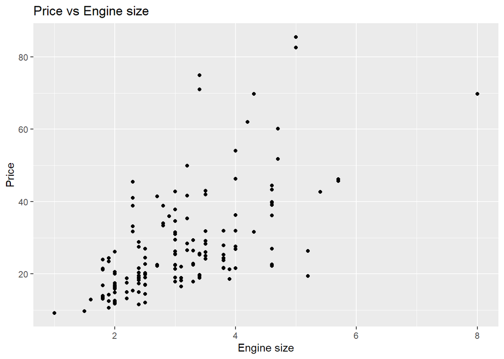

```r
ggplot(data = car_sales, aes(x = engine_s, y = price)) +
  geom_point(na.rm=T) +
  xlab('Engine size') +
  ylab('Price') +
  ggtitle('Price vs Engine size')
```

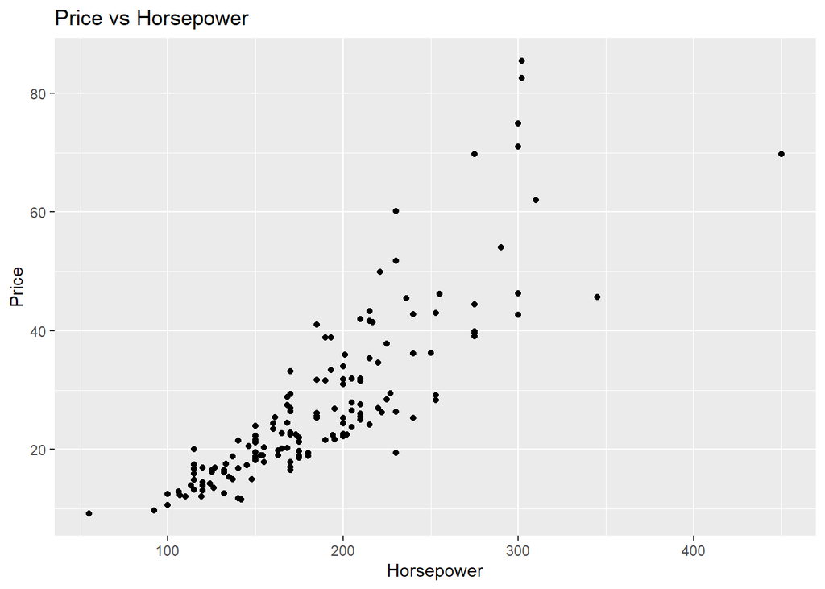

```r
ggplot(data = car_sales, aes(x = horsepow, y = price)) +
  geom_point(na.rm=T) +
  xlab('Horsepower') +
  ylab('Price') +
  ggtitle('Price vs Horsepower')
```

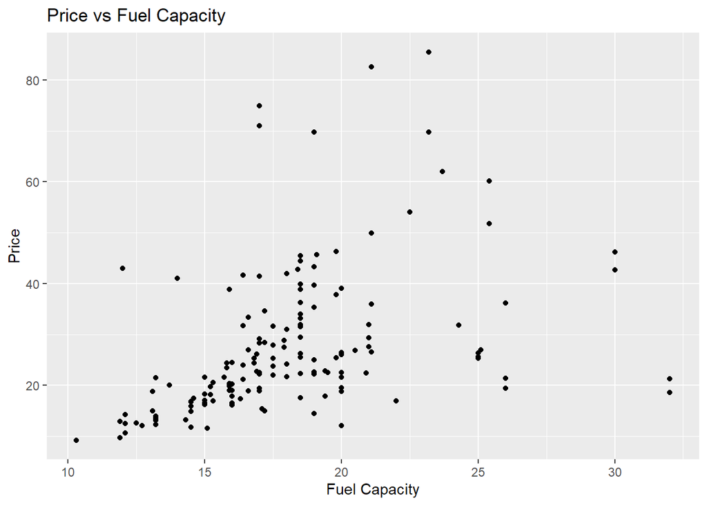

```r
ggplot(data = car_sales, aes(x = fuel_cap, y = price)) +
  geom_point(na.rm=T) +
  xlab('Fuel Capacity') +
  ylab('Price') +
  ggtitle('Price vs Fuel Capacity')
```

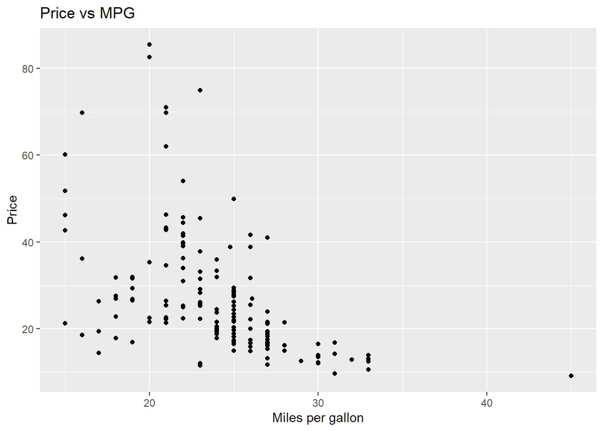

```r
ggplot(data = car_sales, aes(x = mpg, y = price)) +
  geom_point(na.rm=T) +
  xlab('Miles per gallon') +
  ylab('Price') +
  ggtitle('Price vs MPG')
```

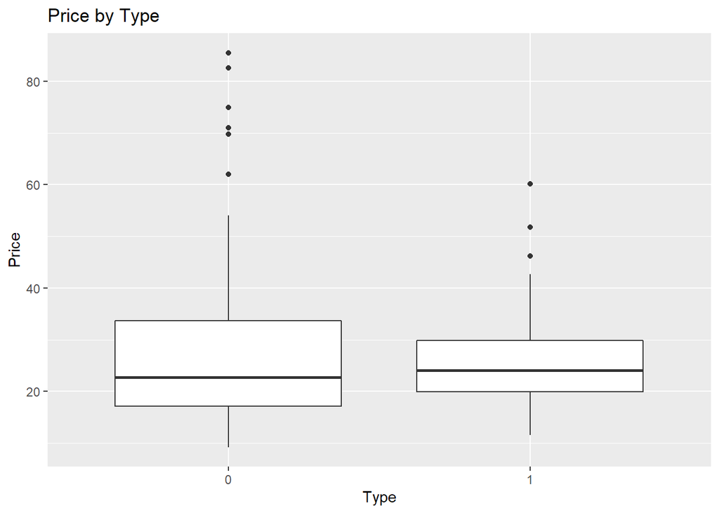

```r
ggplot(data = car_sales, aes(x = type, y = price)) +
  geom_boxplot() +
  xlab('Type') +
  ylab('Price') +
  ggtitle('Price by Type')
```

Στη συνέχεια υπολογίζουμε το συντελεστή συσχέτισης του Pearson για τα αριθμητικά δεδομένα

```r
numeric_sales<-na.omit(car_sales[, sapply(car_sales, is.numeric)])
```

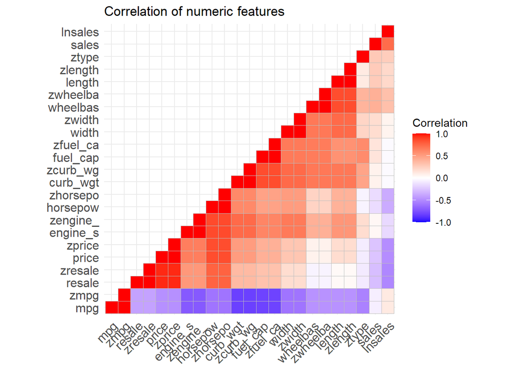

```r
ggcorrplot(cor(numeric_sales), method= "square",type= "lower",show.legend= TRUE,legend.title  = "Correlation",show.diag= TRUE,hc.order= TRUE,colors = c("blue", "white", "red"),title='Correlation of numeric features')
```

## Διερευνητική Παραγοντική Ανάλυση (Exploratory factor analysis)

Χρησιμοποιούμε το πακέτο psych και την εντολή fa.parallel για να προσδιορίσουμε τον αριθμό των παραγόντων. Όπως φαίνεται παρακάτω, ο συνιστόμενος αριθμός είναι 3 παράγοντες. Επιπλέον εκτυπώνονται τα αποτελέσματα και γραφικά.

```
## In smc, smcs < 0 were set to .0
```

```
## In smc, smcs < 0 were set to .0
```

```
## In smc, smcs < 0 were set to .0
```

```
## In factor.scores, the correlation matrix is singular, an approximation is used
```

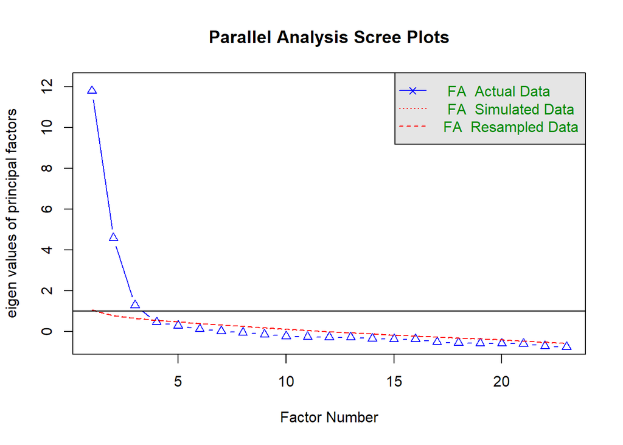

```
## Parallel analysis suggests that the number of factors =  3  and the number of components =  NA
```

```r
fa.parallel(numeric_sales, fm = 'minres', fa = 'fa')
```

## Επιβεβαιωτική Παραγοντική Ανάλυση (Confirmatory factor analysis)

Τώρα χρησιμοποιόυμε την εντολή fa() για να διεξάγουμε Ανάλυση Παραγόντων με n=3. Για μέθοδο περιστρoφής των αξόνων χρησιμοποιούμε την oblimin που επιτρέπει να υπάρχει συσχέτιση μεταξύ των παραγόντων. Τα αποτελέσματα φαίνονται παρακάτω

```r
factors<-fa(numeric_sales,nfactors = 3,fm="minres", rotate="oblimin")
```

```
## In smc, smcs < 0 were set to .0
```

```
## In smc, smcs < 0 were set to .0
```

```
## In smc, smcs < 0 were set to .0
```

```
## In factor.stats, I could not find the RMSEA upper bound . Sorry about that
```

```
## In factor.scores, the correlation matrix is singular, an approximation is used
```

```r
print(factors)
```

```
## Factor Analysis using method =  minres
## Call: fa(r = numeric_sales, nfactors = 3, rotate = "oblimin", fm = "minres")
## Standardized loadings (pattern matrix) based upon correlation matrix
##            MR2   MR1   MR3   h2    u2 com
## sales    -0.42  0.36  0.12 0.27 0.729 2.1
## resale    0.95 -0.20  0.05 0.87 0.127 1.1
## price     0.96 -0.04  0.04 0.93 0.072 1.0
## engine_s  0.59  0.38  0.21 0.79 0.214 2.0
## horsepow  0.87  0.25 -0.01 0.91 0.088 1.2
## wheelbas -0.21  0.81  0.23 0.84 0.155 1.3
## width     0.16  0.71  0.17 0.75 0.254 1.2
## length    0.01  1.00 -0.08 0.93 0.075 1.0
## curb_wgt  0.26  0.39  0.56 0.89 0.110 2.2
## fuel_cap  0.13  0.21  0.76 0.88 0.124 1.2
## mpg      -0.28 -0.06 -0.77 0.86 0.141 1.3
## lnsales  -0.63  0.35  0.08 0.43 0.568 1.6
## zresale   0.95 -0.20  0.05 0.87 0.127 1.1
## ztype    -0.35 -0.21  0.95 0.71 0.292 1.4
## zprice    0.96 -0.04  0.04 0.93 0.072 1.0
## zengine_  0.59  0.38  0.21 0.79 0.214 2.0
## zhorsepo  0.87  0.25 -0.01 0.91 0.088 1.2
## zwheelba -0.21  0.81  0.23 0.84 0.155 1.3
## zwidth    0.16  0.71  0.17 0.75 0.254 1.2
## zlength   0.01  1.00 -0.08 0.93 0.075 1.0
## zcurb_wg  0.26  0.39  0.56 0.89 0.110 2.2
## zfuel_ca  0.13  0.21  0.76 0.88 0.124 1.2
## zmpg     -0.28 -0.06 -0.77 0.86 0.141 1.3
##
##                        MR2  MR1  MR3
## SS loadings           7.33 6.26 5.10
## Proportion Var        0.32 0.27 0.22
## Cumulative Var        0.32 0.59 0.81
## Proportion Explained  0.39 0.33 0.27
## Cumulative Proportion 0.39 0.73 1.00
##
##  With factor correlations of
##      MR2  MR1  MR3
## MR2 1.00 0.22 0.30
## MR1 0.22 1.00 0.51
## MR3 0.30 0.51 1.00
##
## Mean item complexity =  1.4
## Test of the hypothesis that 3 factors are sufficient.
##
## The degrees of freedom for the null model are  253  and the objective function was  239.2 with Chi Square of  25714.4
## The degrees of freedom for the model are 187  and the objective function was  205.71
##
## The root mean square of the residuals (RMSR) is  0.05
## The df corrected root mean square of the residuals is  0.06
##
## The harmonic number of observations is  117 with the empirical chi square  161.57  with prob <  0.91
## The total number of observations was  117  with Likelihood Chi Square =  21702.22  with prob <  0
##
## Tucker Lewis Index of factoring reliability =  -0.165
## RMSEA index =  0.992  and the 90 % confidence intervals are  0.985 NA
## BIC =  20811.7
## Fit based upon off diagonal values = 0.99
## Measures of factor score adequacy
##                                                    MR2  MR1  MR3
## Correlation of (regression) scores with factors   0.99 0.99 0.98
## Multiple R square of scores with factors          0.98 0.98 0.96
## Minimum correlation of possible factor scores     0.97 0.95 0.93
```

H ρίζα του μέσου τετραγώνου υπολείμματος (Root Mean Square Residual) είναι ίση με 0.05 που είναι αρκετά μικρό ώστε να θεωρήσουμε αξιόπιστη τη χρήση τριών παραγόντων.

Τα αποτελέσματα μπορούμε να τα δούμε και οπτικά με την εντολή fa.diagram()

Εδώ φαίνεται πιο καθαρά η συσχέτιση που έχει κάθε παράγοντας με τις επιμέρους μεταβλητέςκαθώς και μεταξύ τους.

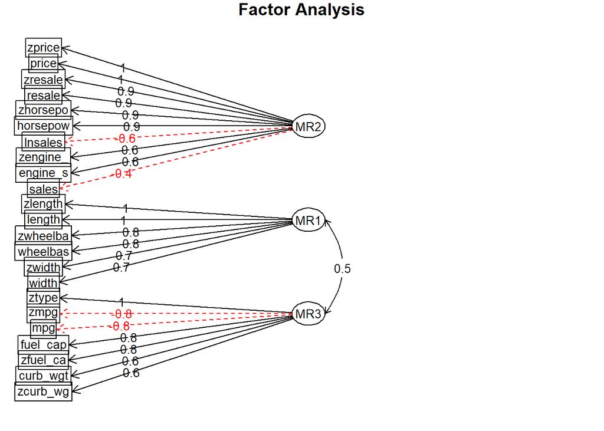

```r
fa.diagram(factors)
```

Επιλέγουμε να απεικονιστούν αυτές που με συσχέτιση από 0.7 και άνω.

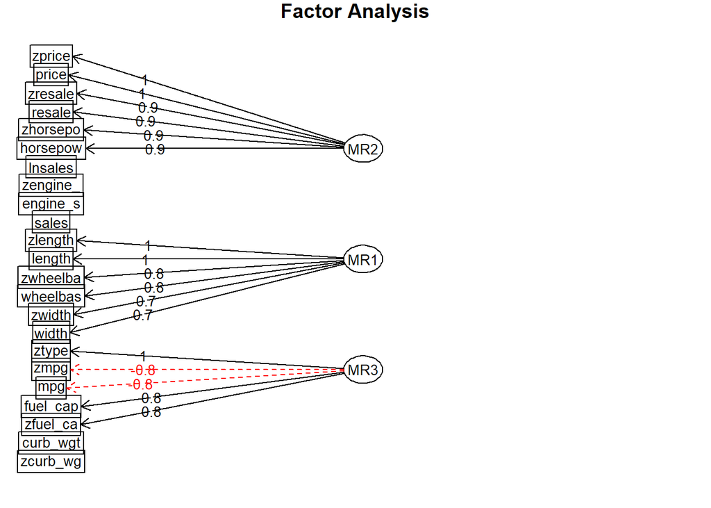

```r
fa.diagram(factors,cut=0.7)
```